# Module 03 - Régression linéaire

MQT-2101 - Analyse et modélisation des données

## Objectifs du module

- Formuler une question et lire les données.
- Interpréter une droite ajustée avec R.
- Examiner les résidus et les limites des prédictions.
- Rédiger une conclusion appuyée sur les résultats.

## Le cas étudié

60

observations mois-région

5

régions québécoises

12

mois en 2025

## Les variables et leurs rôles

Réponse : ventes

Montant mensuel des ventes, en dollars.

Explicative : budget_marketing

Budget marketing mensuel, en dollars.

La région, la saison et le canal de campagne donnent le contexte.

## La question statistique

Dans ces données, comment les ventes moyennes varient-elles selon le budget marketing?

Comparer des budgets différents, pendant un mois, dans les régions observées.

## Lecture du nuage de points

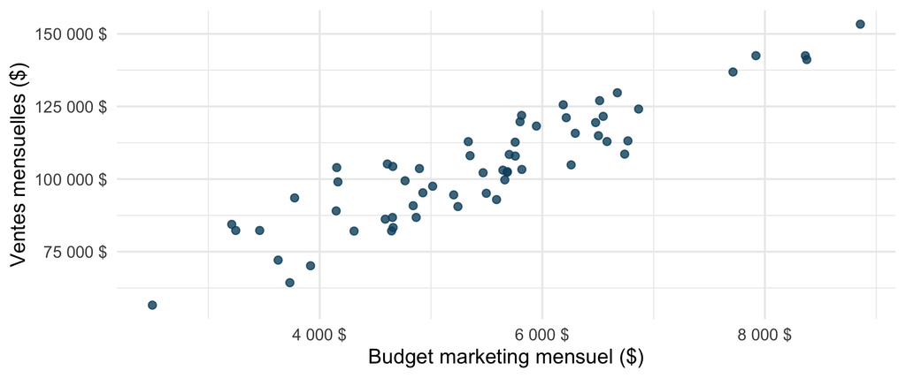

## La corrélation linéaire

$r$ décrit la direction et l’intensité de la relation linéaire.

$-1$

Alignement décroissant

$0$

Absence de relation linéaire

$+1$

Alignement croissant

Sans unité. Symétrique en $x$ et $y$. Une relation courbe peut avoir une corrélation faible.

## Le modèle et la moyenne

$$Y_i = \beta_0 + \beta_1 x_i + \varepsilon_i$$

$$\mathrm{E}(Y_i \mid x_i) = \beta_0 + \beta_1 x_i$$

$x_i$ : budget. $Y_i$ : ventes. $\varepsilon_i$ : écart aléatoire non observé.

## La droite estimée

$$\widehat{y}_i = \widehat{\beta}_0 + \widehat{\beta}_1 x_i$$

Pente estimée

Différence de ventes moyennes estimée pour 1 $ de budget supplémentaire.

Ordonnée à l’origine estimée

Ventes prédites lorsque le budget vaut 0 $.

## Une comparaison de 1 000 $

Pente estimée : 13,58 $ de ventes par dollar de budget.

Pour 1 000 $ de budget supplémentaire : environ 13 582 $ de ventes moyennes supplémentaires selon la droite.

Une association estimée dans ces données simulées.

## Le budget nul est hors de la plage observée

2 497 $

Budget minimal observé

8 857 $

Budget maximal observé

0 $

Extrapolation

L’ordonnée estimée vaut 29 922 $. Son interprétation à budget nul n’est pas appuyée par ces observations.

## Un résidu se calcule sur une observation

$$e_i = y_i - \widehat{y}_i$$

121 915 $

Ventes observées

108 888 $

Ventes prédites

+13 027 $

Résidu, après arrondi

Capitale-Nationale, janvier 2025. Budget : 5 814 $.

## Le principe des moindres carrés

$$\sum_{i=1}^{n} e_i^2 = \sum_{i=1}^{n}(y_i-\widehat{y}_i)^2$$

La droite ajustée minimise cette somme.

Les carrés évitent que les écarts positifs et négatifs s’annulent. Les grands écarts pèsent davantage.

## Les coefficients calculés

```
     (Intercept) budget_marketing
       29922.107           13.582
```

`(Intercept)` : ordonnée à l’origine. `budget_marketing` : pente.

La droite estimée : ventes prédites = 29 922,11 + 13,58 × budget.

## L’incertitude sur la pente

```
                    2.5 %   97.5 %
budget_marketing 11.93333 15.23067
```

Intervalle de confiance classique à 95 % : de 11,93 à 15,23 $ de ventes par dollar de budget.

Pour 1 000 $ de budget, multipliez aussi les deux bornes par 1 000 : de 11 933 à 15 231 $ de ventes moyennes supplémentaires.

## Les hypothèses restent à examiner

Relation moyenne linéaire, erreurs indépendantes, dispersion constante.

Ici, les mêmes régions reviennent chaque mois. Les résidus et le contexte doivent être examinés avant de faire confiance aux intervalles.

## Poser la question du test

$$H_0 : \beta_1 = 0 \qquad H_1 : \beta_1 \ne 0$$

H₀ est l’hypothèse nulle : la pente de population est nulle.

Le test porte sur une association linéaire dans le modèle. Il ne démontre pas un effet causal du budget.

## Lire la ligne de la pente

```r
summary(modele)$coefficients["budget_marketing", ]
```

```
    Estimate   Std. Error      t value     Pr(>|t|)
1.358200e+01 8.236280e-01 1.649046e+01 1.458098e-23
```

Estimate : pente estimée. Std. Error : erreur-type. t value : statistique du test. Pr(>|t|) : valeur p bilatérale.

$$t = \frac{\widehat{\beta}_1 - 0}{\operatorname{SE}(\widehat{\beta}_1)}$$

## Que signifie la valeur p?

Sous H₀ et les hypothèses du modèle, la valeur p est la probabilité d’obtenir une statistique au moins aussi extrême que celle observée.

Pour ce test bilatéral, « aussi extrême » signifie aussi loin de zéro, dans l’un ou l’autre sens.

Une petite valeur p indique une moins bonne compatibilité des données avec H₀. Ce n’est pas la probabilité que H₀ soit vraie.

## Décider sous des hypothèses

- Au seuil fixé α = 0,05, on rejette H₀ si p ≤ 0,05.
- Sinon, on ne rejette pas H₀ : on n’a pas prouvé que la pente est nulle.
- Ici, p < 0,001; le calcul suppose les hypothèses classiques valides.

La valeur p ne mesure ni l’ampleur de l’association ni son importance pratique. Il faut aussi lire la pente, son intervalle et les diagnostics.

## Les résidus selon les ventes prédites

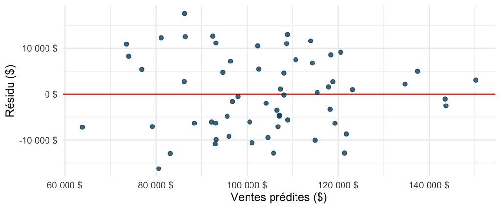

## La moyenne des résidus par région

| Région | Résidu moyen ($) |
| --- | --- |
| Capitale-Nationale | 5676 |
| Estrie | -3340 |
| Mauricie | -226 |
| Montréal | 2956 |
| Outaouais | -5066 |

Capitale-Nationale : sous-estimation moyenne. Outaouais : surestimation moyenne.

## Résultats du diagnostic

La droite décrit la tendance globale, mais les écarts régionaux méritent une analyse complémentaire.

Les mêmes régions sont observées sur plusieurs mois. Ce graphique seul ne vérifie pas l’indépendance des erreurs.

## Le coefficient de détermination

$$R^2 = 1-\frac{\sum_i(y_i-\widehat{y}_i)^2}{\sum_i(y_i-\bar y)^2}$$

Ici : 0,824, soit environ 82,4 % de la variation des ventes décrite par la droite.

Calcul sur les observations qui ont servi à ajuster le modèle.

## Deux sommes de carrés

$$\mathrm{SSE}=\sum_i(y_i-\widehat{y}_i)^2
\qquad
\mathrm{SST}=\sum_i(y_i-\bar y)^2$$

SSE : somme résiduelle

Écarts au carré entre les observations et la droite.

SST : somme totale

Écarts au carré entre les observations et leur moyenne.

Avec une ordonnée à l’origine : R² = 1 − SSE / SST, si SST > 0.

## Passer du rapport au pourcentage

Exemple : SSE = 30 et SST = 120.

$$R^2=1-\frac{30}{120}=0{,}75=75\,\%$$

La droite explique 75 % de la variation observée autour de la moyenne. Les 25 % restants correspondent à la variation résiduelle.

0,75 est une proportion; 75 % est le pourcentage correspondant.

## La plage de prédiction

2 497 $

Budget minimal observé

6 000 $

Exemple dans la plage

8 857 $

Budget maximal observé

Prédire au-delà de cette plage est une extrapolation. Dans la plage, le contexte doit aussi rester comparable.

## Une prédiction accompagnée de son intervalle

111 414 $

Ventes prédites pour 6 000 $ de budget

94 560 $

Borne inférieure

128 268 $

Borne supérieure

Intervalle de prédiction classique à 95 %, sous les hypothèses du modèle.

## Moyenne et nouvelle observation

Intervalle de confiance

Incertitude sur les ventes moyennes pour un budget donné.

Intervalle de prédiction

Incertitude pour une nouvelle observation, y compris sa dispersion autour de la moyenne.

Pour le même budget et le même niveau, l’intervalle de prédiction est plus large.

## Une conclusion appuyée sur les résultats

Pour 1 000 $ de budget supplémentaire, la droite estime environ 13 582 $ de ventes moyennes supplémentaires.

Elle décrit 82,4 % de la variation observée. Les résidus moyens varient selon la région. Ces données simulées ne prouvent pas qu’augmenter le budget provoquerait cette hausse des ventes.

## Références

- R Core Team : documentation de [lm()](https://stat.ethz.ch/R-manual/R-devel/library/stats/html/lm.html) et [predict.lm()](https://stat.ethz.ch/R-manual/R-devel/library/stats/html/predict.lm.html).
- NIST/SEMATECH : [diagnostic des modèles par les résidus](https://www.itl.nist.gov/div898/handbook/pmd/section4/pmd44.htm).
- Données simulées du cours : campagnes régionales en 2025.

## Votre travail

Le parcours guidé construit le rapport sur le budget et les ventes. Les démonstrations R donnent le code complet.

Les exercices et corrigés permettent ensuite de transférer la démarche au délai de service et à la satisfaction.